# lab5

Nikitin Dmitry

5 декабря 2018 г

# Дисперсионный анализ

Загрузим данные

```r
data = read.csv("/home/dmitry/Документы/Учеба/MD-DA-2018-Results/Labs/lab5/diet.csv",row.names=1)
summary
```

```
## function (object, ...)
## UseMethod("summary")
## <bytecode: 0x55b7584a8798>
## <environment: namespace:base>
```

Ознакомимся со структурой и переименуем колонки, как нам удобно https://www.sheffield.ac.uk/polopoly_fs/1.547015!/file/Diet_data_description.docx https://www.sheffield.ac.uk/mash/data

```r
colnames(data) <- c("gender", "age", "height", "initial.weight",
                    "diet.type", "final.weight")
data$diet.type <- factor(c("A", "B", "C")[data$diet.type])
```

Добавим новую колонку - Похудение

```r
data$weight.loss = data$initial.weight - data$final.weight
```

Проанализиуем есть ли различия по типам диет

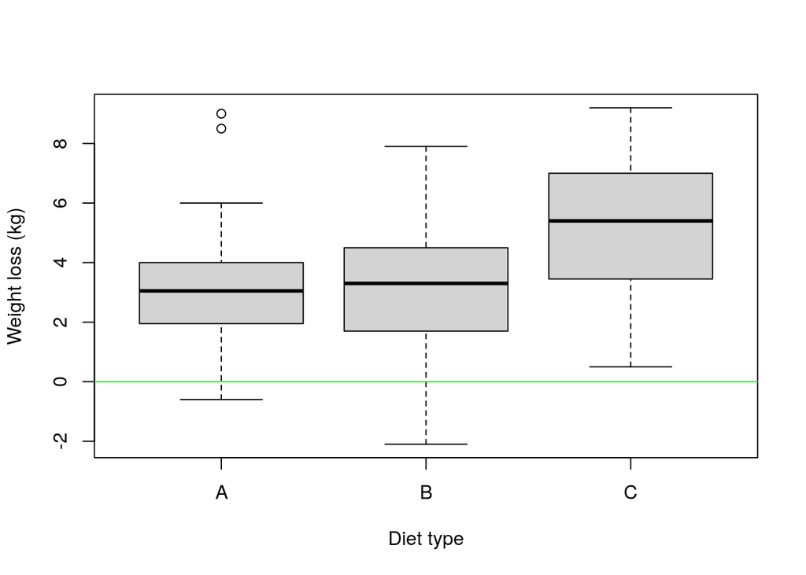

```r
boxplot(weight.loss~diet.type,data=data,col="light gray",
        ylab = "Weight loss (kg)", xlab = "Diet type")
abline(h=0,col="green")
```

проверим сбалансированные ли данные

```r
table(data$diet.type)
```

```
##
##  A  B  C
## 24 27 27
```

График групповых средних

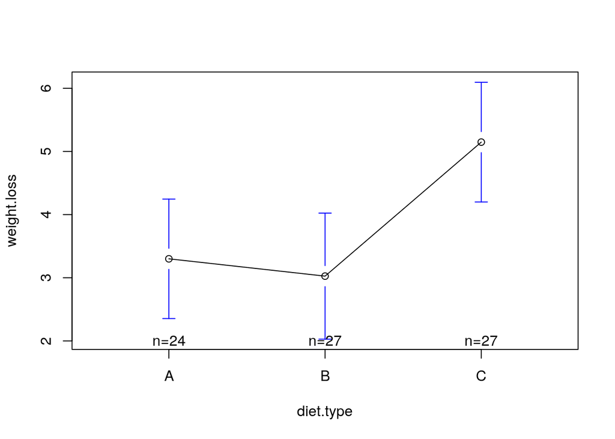

```r
library(gplots) #библиотека устанавлевается с помощью install.packages
plotmeans(weight.loss ~ diet.type, data=data)
```

```r
aggregate(data$weight.loss, by = list(data$diet.type), FUN=sd)
```

```
##   Group.1        x
## 1       A 2.240148
## 2       B 2.523367
## 3       C 2.395568
```

Для подгонки ANOVA модели используем функцию aov, частный случай линейной модели lm тест на межгрупповые различия

```r
fit <- aov(weight.loss ~ diet.type, data=data)
summary(fit)
```

```
##             Df Sum Sq Mean Sq F value  Pr(>F)
## diet.type    2   71.1   35.55   6.197 0.00323 **
## Residuals   75  430.2    5.74
## ---
## Signif. codes:  0 '***' 0.001 '**' 0.01 '*' 0.05 '.' 0.1 ' ' 1
```

попарные различия между средними значениями для всех групп

```r
TukeyHSD(fit)
```

```
##   Tukey multiple comparisons of means
##     95% family-wise confidence level
##
## Fit: aov(formula = weight.loss ~ diet.type, data = data)
##
## $diet.type
##           diff        lwr      upr     p adj
## B-A -0.2740741 -1.8806155 1.332467 0.9124737
## C-A  1.8481481  0.2416067 3.454690 0.0201413
## C-B  2.1222222  0.5636481 3.680796 0.0047819
```

Tukey honest significant differences test

```r
library(multcomp)
```

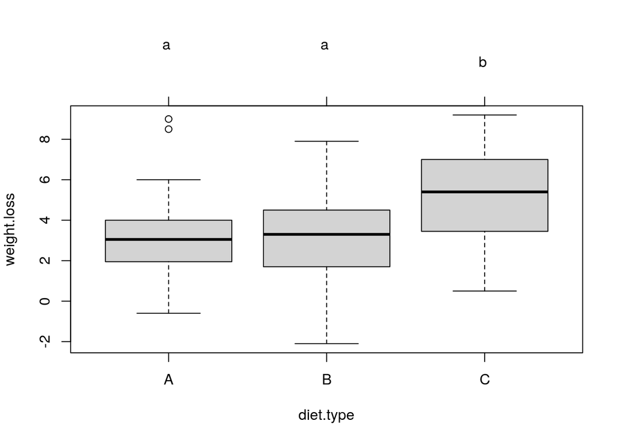

```r
par(mar=c(5,4,6,2))
tuk <- glht(fit, linfct=mcp(diet.type="Tukey"))
plot(cld(tuk, level=.05),col="lightgrey")
```

# Задание

Добавить проверку на выборы и избавиться от них

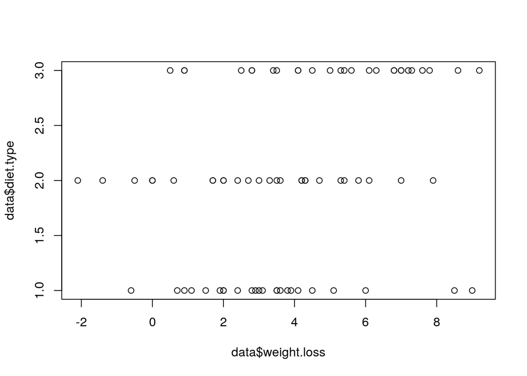

```r
plot(data$weight.loss,data$diet.type)
```

```r
data.noout<-data[data$weight.loss<=8,]
```

повторно проверсти все тесты и сравнить результаты с выбросами и без

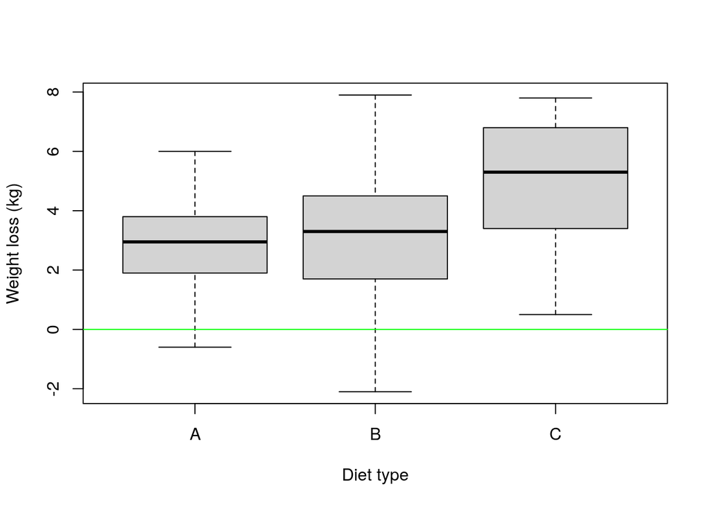

```r
boxplot(weight.loss~diet.type,data=data.noout,col="light gray",
        ylab = "Weight loss (kg)", xlab = "Diet type")
abline(h=0,col="green")
```

График групповых средних

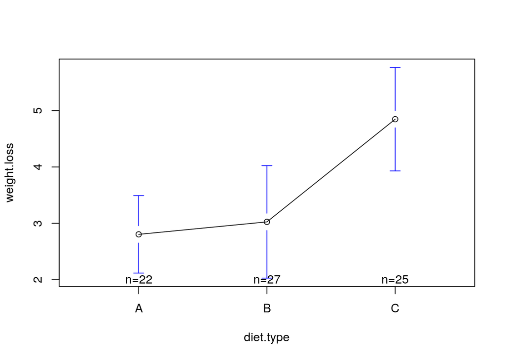

```r
plotmeans(weight.loss ~ diet.type, data=data.noout)
```

```r
aggregate(data$weight.loss, by = list(data$diet.type), FUN=sd)
```

```
##   Group.1        x
## 1       A 2.240148
## 2       B 2.523367
## 3       C 2.395568
```

Для подгонки ANOVA модели используем функцию aov, частный случай линейной модели lm тест на межгрупповые различия

```r
fit.noout <- aov(weight.loss ~ diet.type, data=data.noout)
summary(fit.noout)
```

```
##             Df Sum Sq Mean Sq F value  Pr(>F)
## diet.type    2   61.7  30.856   6.546 0.00246 **
## Residuals   71  334.7   4.714
## ---
## Signif. codes:  0 '***' 0.001 '**' 0.01 '*' 0.05 '.' 0.1 ' ' 1
```

Попарные различия между средними значениями для всех групп

```r
TukeyHSD(fit.noout)
```

```
##   Tukey multiple comparisons of means
##     95% family-wise confidence level
##
## Fit: aov(formula = weight.loss ~ diet.type, data = data.noout)
##
## $diet.type
##          diff        lwr      upr     p adj
## B-A 0.2213805 -1.2713237 1.714085 0.9329494
## C-A 2.0434545  0.5241792 3.562730 0.0054330
## C-B 1.8220741  0.3795645 3.264584 0.0096111
```

Tukey honest significant differences test)

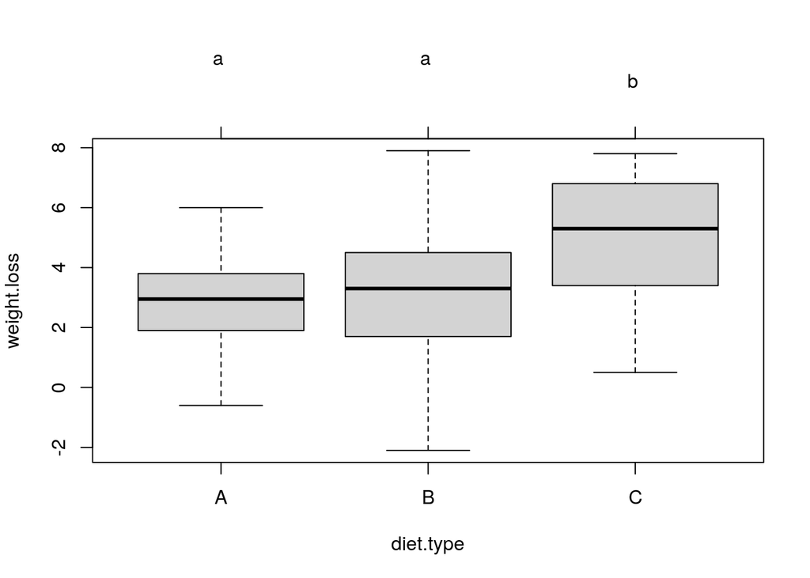

```r
par(mar=c(5,4,6,2))
tuk <- glht(fit.noout, linfct=mcp(diet.type="Tukey"))
plot(cld(tuk, level=.05),col="lightgrey")
```

После удаления выбросов самой лучшей диетой так и осталась диета С, а самой худшей диетой вместо диеты В стала диета А.

Открыть документ https://www.sheffield.ac.uk/polopoly_fs/1.547015!/file/Diet_data_description.docx и попытаться выполнить задания из него

```r
data.noout.with.gender<-data[!is.na(data$gender),]
data.noout.with.gender$gender <- factor(c("Female","Male")[as.ordered(data.noout.with.gender$gender)])
```

Effect of diet and gender on weight lost

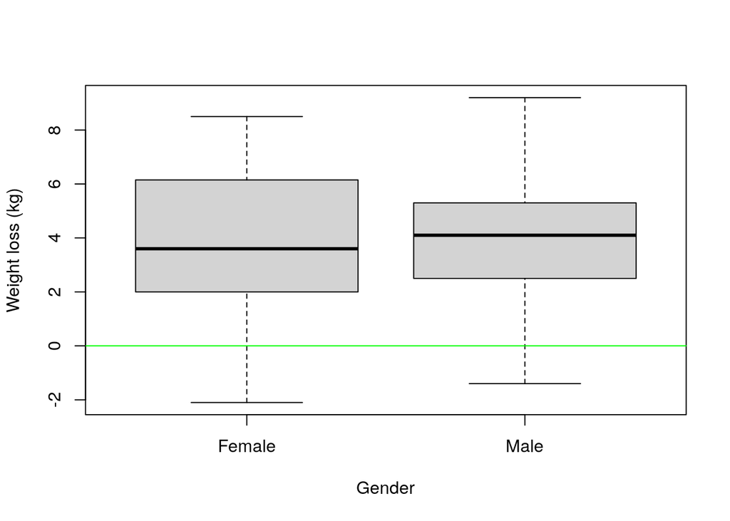

```r
boxplot(weight.loss~gender,data=data.noout.with.gender,col="light gray",
        ylab = "Weight loss (kg)", xlab = "Gender")
abline(h=0,col="green")
```

График групповых средних

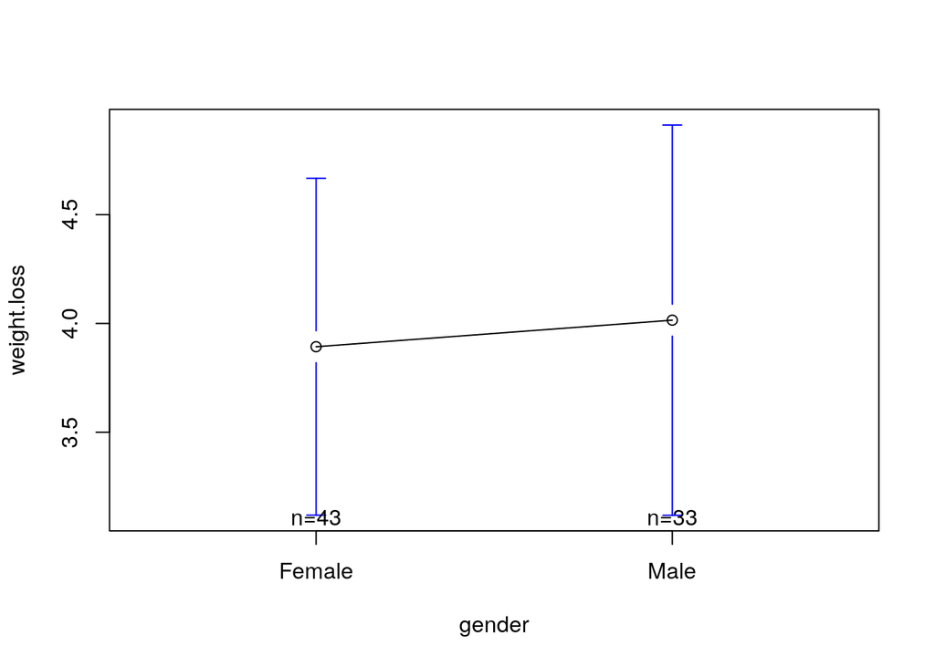

```r
plotmeans(weight.loss ~ gender, data=data.noout.with.gender)
```

```r
aggregate(data.noout.with.gender$weight.loss, by = list(data.noout.with.gender$gender), FUN=sd)
```

```
##   Group.1        x
## 1  Female 2.515892
## 2    Male 2.529837
```

Для подгонки ANOVA модели используем функцию aov, частный случай линейной модели lm тест на межгрупповые различия

```r
fit.noout <- aov(weight.loss ~ gender, data=data.noout.with.gender)
summary(fit.noout)
```

```
##             Df Sum Sq Mean Sq F value Pr(>F)
## gender       1    0.3   0.278   0.044  0.835
## Residuals   74  470.7   6.360
```

Попарные различия между средними значениями для всех групп

```r
TukeyHSD(fit.noout)
```

```
##   Tukey multiple comparisons of means
##     95% family-wise confidence level
##
## Fit: aov(formula = weight.loss ~ gender, data = data.noout.with.gender)
##
## $gender
##                  diff      lwr      upr     p adj
## Male-Female 0.1221283 -1.04081 1.285067 0.8348274
```

Tukey honest significant differences test)

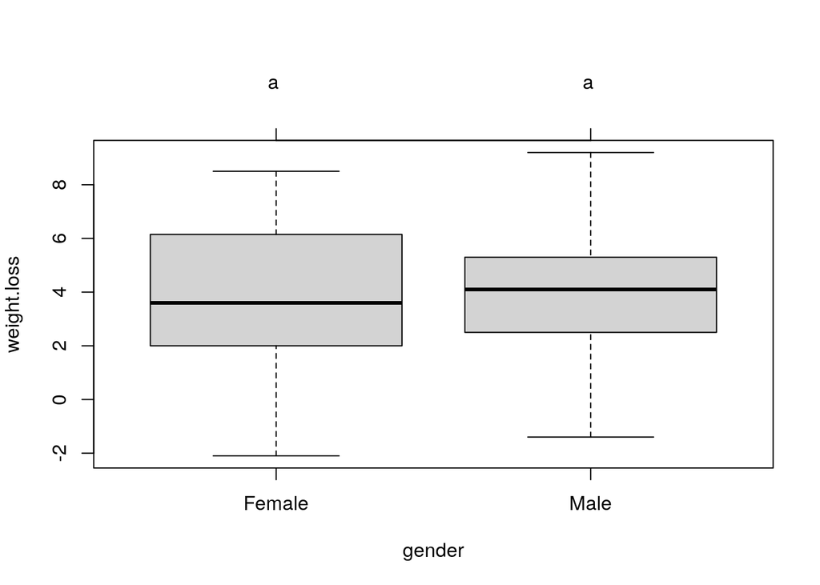

```r
par(mar=c(5,4,6,2))
tuk <- glht(fit.noout, linfct=mcp(gender="Tukey"))
plot(cld(tuk, level=.05),col="lightgrey")
```

Можно сказать, что потеря веса не зависит от пола